# Optimal Treatment Analysis

## Outcome Variable

**Outcome Variable:** ever_wasted

## Predictor Variables

**Intervention Variable:** hfoodsec

**Adjustment Set:**

- arm
- sex
- W_mage
- meducyrs
- feducyrs
- hhwealth_quart
- vagbrth
- W_nrooms
- W_nchldlt5
- brthmon
- W_parity
- impfloor
- impsan
- safeh20
- delta_W_mage
- delta_meducyrs
- delta_feducyrs
- delta_hhwealth_quart
- delta_vagbrth
- delta_W_nrooms
- delta_W_nchldlt5
- delta_brthmon
- delta_W_parity
- delta_impfloor
- delta_impsan
- delta_safeh20

## Stratifying Variables

The analysis was stratified on these variable(s):

- agecat
- studyid
- country

## Data Summary

| agecat | studyid | country | hfoodsec | ever_wasted | n_cell | n |
| --- | --- | --- | --- | --- | --- | --- |
| 0-24 months | ki0047075b-MAL-ED | BANGLADESH | Food Secure | 0 | 105 | 194 |
| 0-24 months | ki0047075b-MAL-ED | BANGLADESH | Food Secure | 1 | 56 | 194 |
| 0-24 months | ki0047075b-MAL-ED | BANGLADESH | Mildly Food Insecure | 0 | 3 | 194 |
| 0-24 months | ki0047075b-MAL-ED | BANGLADESH | Mildly Food Insecure | 1 | 1 | 194 |
| 0-24 months | ki0047075b-MAL-ED | BANGLADESH | Food Insecure | 0 | 19 | 194 |
| 0-24 months | ki0047075b-MAL-ED | BANGLADESH | Food Insecure | 1 | 10 | 194 |
| 0-24 months | ki0047075b-MAL-ED | BRAZIL | Food Secure | 0 | 3 | 129 |
| 0-24 months | ki0047075b-MAL-ED | BRAZIL | Food Secure | 1 | 0 | 129 |
| 0-24 months | ki0047075b-MAL-ED | BRAZIL | Mildly Food Insecure | 0 | 11 | 129 |
| 0-24 months | ki0047075b-MAL-ED | BRAZIL | Mildly Food Insecure | 1 | 0 | 129 |
| 0-24 months | ki0047075b-MAL-ED | BRAZIL | Food Insecure | 0 | 104 | 129 |
| 0-24 months | ki0047075b-MAL-ED | BRAZIL | Food Insecure | 1 | 11 | 129 |
| 0-24 months | ki0047075b-MAL-ED | INDIA | Food Secure | 0 | 98 | 212 |
| 0-24 months | ki0047075b-MAL-ED | INDIA | Food Secure | 1 | 92 | 212 |
| 0-24 months | ki0047075b-MAL-ED | INDIA | Mildly Food Insecure | 0 | 1 | 212 |
| 0-24 months | ki0047075b-MAL-ED | INDIA | Mildly Food Insecure | 1 | 4 | 212 |
| 0-24 months | ki0047075b-MAL-ED | INDIA | Food Insecure | 0 | 10 | 212 |
| 0-24 months | ki0047075b-MAL-ED | INDIA | Food Insecure | 1 | 7 | 212 |
| 0-24 months | ki0047075b-MAL-ED | NEPAL | Food Secure | 0 | 65 | 128 |
| 0-24 months | ki0047075b-MAL-ED | NEPAL | Food Secure | 1 | 29 | 128 |
| 0-24 months | ki0047075b-MAL-ED | NEPAL | Mildly Food Insecure | 0 | 11 | 128 |
| 0-24 months | ki0047075b-MAL-ED | NEPAL | Mildly Food Insecure | 1 | 4 | 128 |
| 0-24 months | ki0047075b-MAL-ED | NEPAL | Food Insecure | 0 | 10 | 128 |
| 0-24 months | ki0047075b-MAL-ED | NEPAL | Food Insecure | 1 | 9 | 128 |
| 0-24 months | ki0047075b-MAL-ED | PERU | Food Secure | 0 | 22 | 113 |
| 0-24 months | ki0047075b-MAL-ED | PERU | Food Secure | 1 | 5 | 113 |
| 0-24 months | ki0047075b-MAL-ED | PERU | Mildly Food Insecure | 0 | 29 | 113 |
| 0-24 months | ki0047075b-MAL-ED | PERU | Mildly Food Insecure | 1 | 0 | 113 |
| 0-24 months | ki0047075b-MAL-ED | PERU | Food Insecure | 0 | 49 | 113 |
| 0-24 months | ki0047075b-MAL-ED | PERU | Food Insecure | 1 | 8 | 113 |

[output cut: 168 more lines]

The following strata were considered:

- agecat: 0-24 months, studyid: ki0047075b-MAL-ED, country: BANGLADESH
- agecat: 0-24 months, studyid: ki0047075b-MAL-ED, country: BRAZIL
- agecat: 0-24 months, studyid: ki0047075b-MAL-ED, country: INDIA
- agecat: 0-24 months, studyid: ki0047075b-MAL-ED, country: NEPAL
- agecat: 0-24 months, studyid: ki0047075b-MAL-ED, country: PERU
- agecat: 0-24 months, studyid: ki0047075b-MAL-ED, country: SOUTH AFRICA
- agecat: 0-24 months, studyid: ki1017093-NIH-Birth, country: BANGLADESH
- agecat: 0-24 months, studyid: ki1017093c-NIH-Crypto, country: BANGLADESH
- agecat: 0-24 months, studyid: ki1113344-GMS-Nepal, country: NEPAL
- agecat: 0-24 months, studyid: kiGH5241-JiVitA-3, country: BANGLADESH
- agecat: 0-24 months, studyid: kiGH5241-JiVitA-4, country: BANGLADESH
- agecat: 0-6 months, studyid: ki0047075b-MAL-ED, country: BANGLADESH
- agecat: 0-6 months, studyid: ki0047075b-MAL-ED, country: BRAZIL
- agecat: 0-6 months, studyid: ki0047075b-MAL-ED, country: INDIA
- agecat: 0-6 months, studyid: ki0047075b-MAL-ED, country: NEPAL
- agecat: 0-6 months, studyid: ki0047075b-MAL-ED, country: PERU
- agecat: 0-6 months, studyid: ki0047075b-MAL-ED, country: SOUTH AFRICA
- agecat: 0-6 months, studyid: ki1017093-NIH-Birth, country: BANGLADESH
- agecat: 0-6 months, studyid: ki1017093c-NIH-Crypto, country: BANGLADESH
- agecat: 0-6 months, studyid: ki1113344-GMS-Nepal, country: NEPAL
- agecat: 0-6 months, studyid: kiGH5241-JiVitA-3, country: BANGLADESH
- agecat: 0-6 months, studyid: kiGH5241-JiVitA-4, country: BANGLADESH
- agecat: 6-24 months, studyid: ki0047075b-MAL-ED, country: BANGLADESH
- agecat: 6-24 months, studyid: ki0047075b-MAL-ED, country: BRAZIL
- agecat: 6-24 months, studyid: ki0047075b-MAL-ED, country: INDIA
- agecat: 6-24 months, studyid: ki0047075b-MAL-ED, country: NEPAL
- agecat: 6-24 months, studyid: ki0047075b-MAL-ED, country: PERU
- agecat: 6-24 months, studyid: ki0047075b-MAL-ED, country: SOUTH AFRICA
- agecat: 6-24 months, studyid: ki1017093-NIH-Birth, country: BANGLADESH
- agecat: 6-24 months, studyid: ki1017093c-NIH-Crypto, country: BANGLADESH
- agecat: 6-24 months, studyid: ki1113344-GMS-Nepal, country: NEPAL
- agecat: 6-24 months, studyid: kiGH5241-JiVitA-3, country: BANGLADESH
- agecat: 6-24 months, studyid: kiGH5241-JiVitA-4, country: BANGLADESH

### Dropped Strata

Some strata were dropped due to rare outcomes:

- agecat: 0-24 months, studyid: ki0047075b-MAL-ED, country: BANGLADESH
- agecat: 0-24 months, studyid: ki0047075b-MAL-ED, country: BRAZIL
- agecat: 0-24 months, studyid: ki0047075b-MAL-ED, country: INDIA
- agecat: 0-24 months, studyid: ki0047075b-MAL-ED, country: NEPAL
- agecat: 0-24 months, studyid: ki0047075b-MAL-ED, country: PERU
- agecat: 0-24 months, studyid: ki0047075b-MAL-ED, country: SOUTH AFRICA
- agecat: 0-6 months, studyid: ki0047075b-MAL-ED, country: BANGLADESH
- agecat: 0-6 months, studyid: ki0047075b-MAL-ED, country: BRAZIL
- agecat: 0-6 months, studyid: ki0047075b-MAL-ED, country: INDIA
- agecat: 0-6 months, studyid: ki0047075b-MAL-ED, country: NEPAL
- agecat: 0-6 months, studyid: ki0047075b-MAL-ED, country: PERU
- agecat: 0-6 months, studyid: ki0047075b-MAL-ED, country: SOUTH AFRICA
- agecat: 6-24 months, studyid: ki0047075b-MAL-ED, country: BANGLADESH
- agecat: 6-24 months, studyid: ki0047075b-MAL-ED, country: BRAZIL
- agecat: 6-24 months, studyid: ki0047075b-MAL-ED, country: INDIA
- agecat: 6-24 months, studyid: ki0047075b-MAL-ED, country: NEPAL
- agecat: 6-24 months, studyid: ki0047075b-MAL-ED, country: PERU
- agecat: 6-24 months, studyid: ki0047075b-MAL-ED, country: SOUTH AFRICA

## Methods Detail

We’re interested in the causal parameters $E[Y_a]$ for all values of $a \in \mathcal{A}$. These parameters represent the mean outcome if, possibly contrary to fact, we intervened to set all units to have $A=a$. Under the randomization and positivity assumptions, these are identified by the statistical parameters $\psi_a=E_W[E_{Y|A,W}(Y|A=a,W)]$. In addition, we’re interested in the mean of $Y$, $E[Y]$ under no intervention (the observed mean). We will estimate these parameters by using SuperLearner to fit the relevant likelihood factors – $E_{Y|A,W}(Y|A=a,W)$ and $p(A=a|W)$, and then updating our likelihood fit using a joint TMLE.

For unadjusted analyses ($W=\{\}$), initial likelihoods were estimated using Lrnr_glm to estimate the simple $E(Y|A)$ and Lrnr_mean to estimate $p(A)$. For adjusted analyses, a small library containing Lrnr_glmnet, Lrnr_xgboost, and Lrnr_mean was used.

Having estimated these parameters, we will then use the delta method to estimate relative risks and attributable risks relative to a prespecified baseline level of $A$.

# Results Detail

## Results Plots

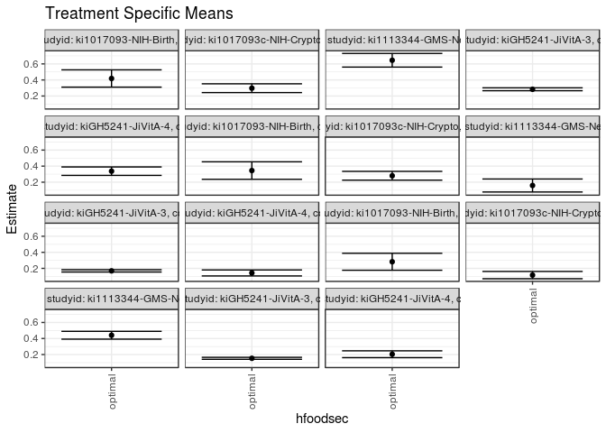

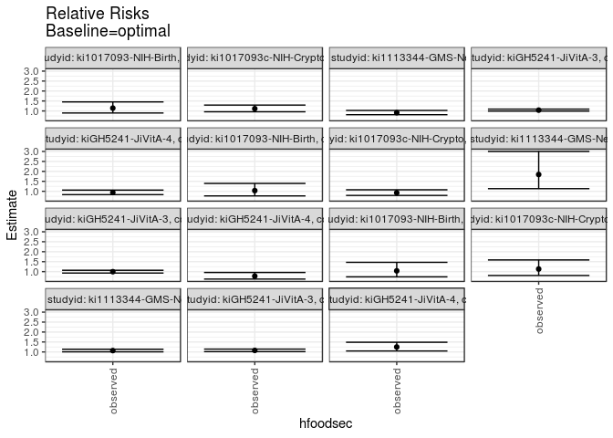

## Results Table

### Parameter: TSM

| agecat | studyid | country | intervention_level | baseline_level | estimate | ci_lower | ci_upper |
| --- | --- | --- | --- | --- | --- | --- | --- |
| 0-24 months | ki1017093-NIH-Birth | BANGLADESH | optimal | NA | 0.4182514 | 0.3105073 | 0.5259955 |
| 0-24 months | ki1017093c-NIH-Crypto | BANGLADESH | optimal | NA | 0.2972674 | 0.2425210 | 0.3520138 |
| 0-24 months | ki1113344-GMS-Nepal | NEPAL | optimal | NA | 0.6453993 | 0.5603851 | 0.7304135 |
| 0-24 months | kiGH5241-JiVitA-3 | BANGLADESH | optimal | NA | 0.2836901 | 0.2657399 | 0.3016403 |
| 0-24 months | kiGH5241-JiVitA-4 | BANGLADESH | optimal | NA | 0.3372378 | 0.2844802 | 0.3899954 |
| 0-6 months | ki1017093-NIH-Birth | BANGLADESH | optimal | NA | 0.3450059 | 0.2361454 | 0.4538663 |
| 0-6 months | ki1017093c-NIH-Crypto | BANGLADESH | optimal | NA | 0.2801197 | 0.2253961 | 0.3348434 |
| 0-6 months | ki1113344-GMS-Nepal | NEPAL | optimal | NA | 0.1589283 | 0.0780032 | 0.2398533 |
| 0-6 months | kiGH5241-JiVitA-3 | BANGLADESH | optimal | NA | 0.1691116 | 0.1546757 | 0.1835476 |
| 0-6 months | kiGH5241-JiVitA-4 | BANGLADESH | optimal | NA | 0.1431148 | 0.1057522 | 0.1804774 |
| 6-24 months | ki1017093-NIH-Birth | BANGLADESH | optimal | NA | 0.2826134 | 0.1769289 | 0.3882980 |
| 6-24 months | ki1017093c-NIH-Crypto | BANGLADESH | optimal | NA | 0.1163055 | 0.0709371 | 0.1616740 |
| 6-24 months | ki1113344-GMS-Nepal | NEPAL | optimal | NA | 0.4406683 | 0.3921610 | 0.4891755 |
| 6-24 months | kiGH5241-JiVitA-3 | BANGLADESH | optimal | NA | 0.1533347 | 0.1407613 | 0.1659081 |
| 6-24 months | kiGH5241-JiVitA-4 | BANGLADESH | optimal | NA | 0.2041806 | 0.1615712 | 0.2467900 |

### Parameter: E(Y)

| agecat | studyid | country | intervention_level | baseline_level | estimate | ci_lower | ci_upper |
| --- | --- | --- | --- | --- | --- | --- | --- |
| 0-24 months | ki1017093-NIH-Birth | BANGLADESH | observed | NA | 0.4775641 | 0.4383415 | 0.5167867 |
| 0-24 months | ki1017093c-NIH-Crypto | BANGLADESH | observed | NA | 0.3311346 | 0.2976093 | 0.3646598 |
| 0-24 months | ki1113344-GMS-Nepal | NEPAL | observed | NA | 0.5890411 | 0.5491031 | 0.6289790 |
| 0-24 months | kiGH5241-JiVitA-3 | BANGLADESH | observed | NA | 0.2952669 | 0.2842955 | 0.3062383 |
| 0-24 months | kiGH5241-JiVitA-4 | BANGLADESH | observed | NA | 0.3164200 | 0.2881624 | 0.3446776 |
| 0-6 months | ki1017093-NIH-Birth | BANGLADESH | observed | NA | 0.3569132 | 0.3192325 | 0.3945938 |
| 0-6 months | ki1017093c-NIH-Crypto | BANGLADESH | observed | NA | 0.2585752 | 0.2273844 | 0.2897660 |
| 0-6 months | ki1113344-GMS-Nepal | NEPAL | observed | NA | 0.2928082 | 0.2558702 | 0.3297463 |
| 0-6 months | kiGH5241-JiVitA-3 | BANGLADESH | observed | NA | 0.1683620 | 0.1594164 | 0.1773076 |
| 0-6 months | kiGH5241-JiVitA-4 | BANGLADESH | observed | NA | 0.1107739 | 0.0906511 | 0.1308967 |
| 6-24 months | ki1017093-NIH-Birth | BANGLADESH | observed | NA | 0.2939002 | 0.2554778 | 0.3323226 |
| 6-24 months | ki1017093c-NIH-Crypto | BANGLADESH | observed | NA | 0.1315068 | 0.1069744 | 0.1560393 |
| 6-24 months | ki1113344-GMS-Nepal | NEPAL | observed | NA | 0.4712042 | 0.4302971 | 0.5121113 |
| 6-24 months | kiGH5241-JiVitA-3 | BANGLADESH | observed | NA | 0.1651419 | 0.1559762 | 0.1743076 |
| 6-24 months | kiGH5241-JiVitA-4 | BANGLADESH | observed | NA | 0.2549435 | 0.2289436 | 0.2809434 |

### Parameter: RR

| agecat | studyid | country | intervention_level | baseline_level | estimate | ci_lower | ci_upper |
| --- | --- | --- | --- | --- | --- | --- | --- |
| 0-24 months | ki1017093-NIH-Birth | BANGLADESH | observed | optimal | 1.1418111 | 0.8975831 | 1.4524922 |
| 0-24 months | ki1017093c-NIH-Crypto | BANGLADESH | observed | optimal | 1.1139284 | 0.9582938 | 1.2948392 |
| 0-24 months | ki1113344-GMS-Nepal | NEPAL | observed | optimal | 0.9126769 | 0.8116109 | 1.0263282 |
| 0-24 months | kiGH5241-JiVitA-3 | BANGLADESH | observed | optimal | 1.0408078 | 0.9911653 | 1.0929366 |
| 0-24 months | kiGH5241-JiVitA-4 | BANGLADESH | observed | optimal | 0.9382697 | 0.8311233 | 1.0592290 |
| 0-6 months | ki1017093-NIH-Birth | BANGLADESH | observed | optimal | 1.0345134 | 0.7670521 | 1.3952349 |
| 0-6 months | ki1017093c-NIH-Crypto | BANGLADESH | observed | optimal | 0.9230881 | 0.7931085 | 1.0743696 |
| 0-6 months | ki1113344-GMS-Nepal | NEPAL | observed | optimal | 1.8423923 | 1.1310772 | 3.0010413 |
| 0-6 months | kiGH5241-JiVitA-3 | BANGLADESH | observed | optimal | 0.9955671 | 0.9285121 | 1.0674646 |
| 0-6 months | kiGH5241-JiVitA-4 | BANGLADESH | observed | optimal | 0.7740213 | 0.6257441 | 0.9574344 |
| 6-24 months | ki1017093-NIH-Birth | BANGLADESH | observed | optimal | 1.0399370 | 0.7374406 | 1.4665168 |
| 6-24 months | ki1017093c-NIH-Crypto | BANGLADESH | observed | optimal | 1.1307015 | 0.8058965 | 1.5864145 |
| 6-24 months | ki1113344-GMS-Nepal | NEPAL | observed | optimal | 1.0692946 | 1.0060157 | 1.1365537 |
| 6-24 months | kiGH5241-JiVitA-3 | BANGLADESH | observed | optimal | 1.0770028 | 1.0144421 | 1.1434216 |
| 6-24 months | kiGH5241-JiVitA-4 | BANGLADESH | observed | optimal | 1.2486176 | 1.0483355 | 1.4871631 |

### Parameter: PAR

| agecat | studyid | country | intervention_level | baseline_level | estimate | ci_lower | ci_upper |
| --- | --- | --- | --- | --- | --- | --- | --- |
| 0-24 months | ki1017093-NIH-Birth | BANGLADESH | optimal | NA | 0.0593127 | -0.0412548 | 0.1598801 |
| 0-24 months | ki1017093c-NIH-Crypto | BANGLADESH | optimal | NA | 0.0338672 | -0.0108865 | 0.0786209 |
| 0-24 months | ki1113344-GMS-Nepal | NEPAL | optimal | NA | -0.0563582 | -0.1319543 | 0.0192378 |
| 0-24 months | kiGH5241-JiVitA-3 | BANGLADESH | optimal | NA | 0.0115768 | -0.0022663 | 0.0254199 |
| 0-24 months | kiGH5241-JiVitA-4 | BANGLADESH | optimal | NA | -0.0208178 | -0.0619068 | 0.0202712 |
| 0-6 months | ki1017093-NIH-Birth | BANGLADESH | optimal | NA | 0.0119073 | -0.0913237 | 0.1151383 |
| 0-6 months | ki1017093c-NIH-Crypto | BANGLADESH | optimal | NA | -0.0215445 | -0.0641774 | 0.0210883 |
| 0-6 months | ki1113344-GMS-Nepal | NEPAL | optimal | NA | 0.1338800 | 0.0552384 | 0.2125215 |
| 0-6 months | kiGH5241-JiVitA-3 | BANGLADESH | optimal | NA | -0.0007497 | -0.0125396 | 0.0110403 |
| 0-6 months | kiGH5241-JiVitA-4 | BANGLADESH | optimal | NA | -0.0323409 | -0.0625763 | -0.0021055 |
| 6-24 months | ki1017093-NIH-Birth | BANGLADESH | optimal | NA | 0.0112867 | -0.0857916 | 0.1083651 |
| 6-24 months | ki1017093c-NIH-Crypto | BANGLADESH | optimal | NA | 0.0152013 | -0.0242260 | 0.0546286 |
| 6-24 months | ki1113344-GMS-Nepal | NEPAL | optimal | NA | 0.0305359 | 0.0037389 | 0.0573329 |
| 6-24 months | kiGH5241-JiVitA-3 | BANGLADESH | optimal | NA | 0.0118072 | 0.0026139 | 0.0210005 |
| 6-24 months | kiGH5241-JiVitA-4 | BANGLADESH | optimal | NA | 0.0507629 | 0.0150648 | 0.0864610 |

### Parameter: PAF

| agecat | studyid | country | intervention_level | baseline_level | estimate | ci_lower | ci_upper |
| --- | --- | --- | --- | --- | --- | --- | --- |
| 0-24 months | ki1017093-NIH-Birth | BANGLADESH | optimal | NA | 0.1241984 | -0.1141029 | 0.3115282 |
| 0-24 months | ki1017093c-NIH-Crypto | BANGLADESH | optimal | NA | 0.1022762 | -0.0435213 | 0.2277034 |
| 0-24 months | ki1113344-GMS-Nepal | NEPAL | optimal | NA | -0.0956779 | -0.2321175 | 0.0256528 |
| 0-24 months | kiGH5241-JiVitA-3 | BANGLADESH | optimal | NA | 0.0392078 | -0.0089134 | 0.0850339 |
| 0-24 months | kiGH5241-JiVitA-4 | BANGLADESH | optimal | NA | -0.0657917 | -0.2031908 | 0.0559171 |
| 0-6 months | ki1017093-NIH-Birth | BANGLADESH | optimal | NA | 0.0333619 | -0.3036924 | 0.2832748 |
| 0-6 months | ki1017093c-NIH-Crypto | BANGLADESH | optimal | NA | -0.0833202 | -0.2608615 | 0.0692216 |
| 0-6 months | ki1113344-GMS-Nepal | NEPAL | optimal | NA | 0.4572274 | 0.1158871 | 0.6667823 |
| 0-6 months | kiGH5241-JiVitA-3 | BANGLADESH | optimal | NA | -0.0044527 | -0.0769919 | 0.0632008 |
| 0-6 months | kiGH5241-JiVitA-4 | BANGLADESH | optimal | NA | -0.2919541 | -0.5980973 | -0.0444579 |
| 6-24 months | ki1017093-NIH-Birth | BANGLADESH | optimal | NA | 0.0384033 | -0.3560414 | 0.3181121 |
| 6-24 months | ki1017093c-NIH-Crypto | BANGLADESH | optimal | NA | 0.1155933 | -0.2408541 | 0.3696477 |
| 6-24 months | ki1113344-GMS-Nepal | NEPAL | optimal | NA | 0.0648040 | 0.0059798 | 0.1201471 |
| 6-24 months | kiGH5241-JiVitA-3 | BANGLADESH | optimal | NA | 0.0714973 | 0.0142365 | 0.1254320 |
| 6-24 months | kiGH5241-JiVitA-4 | BANGLADESH | optimal | NA | 0.1991143 | 0.0461069 | 0.3275788 |